# Caminho aleatório

## Definição

Um caminho aleatório consiste no percurso a uma ou mais dimensões efectuado em passos discretos em que o sentido e ou direcção e eventualmente o comprimento de cada passo são obtidos aleatoriamente de um conjunto ou intervalo predefinido.

Na figura em baixo é possível observar um caminho aleatório a duas dimensões numa rede quadrada com 10 000 passos.

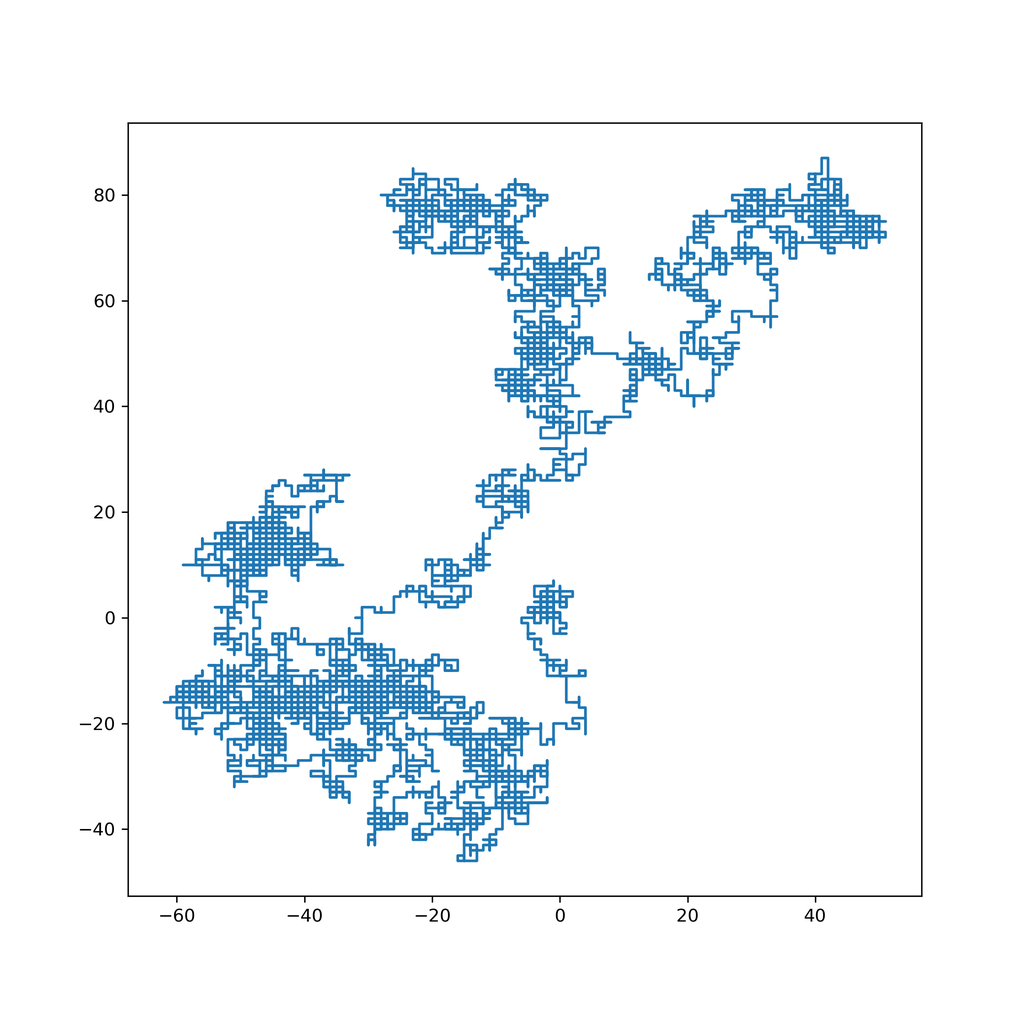

## O caminho aleatório simples

Um caminho aleatório simples, como o exemplo anterior, é um caminho aleatório em que cada passo é independente do passo anterior. Nestes casos, embora seja impossível saber a trajectória e ou posição final de um caminho aleatório, é possível saber analiticamente a posição final média, assim como outras características, de um número elevado de caminhos aleatórios simples.

De facto sabe-se que o vector posição final é obtido nas seguintes condições:

- É a soma dos vectores de cada passo do caminho.
- A probabilidade de sair um dado vector em cada passo é independente dos passos anteriores.
- A adição de vectores é comutativa, ou seja independente da ordem em que os vectores saem.

Considerando uma rede quadrada a posição final de um caminho aleatório simples com n passos é dada por:

$\begin{cases} \vec{r} = i (\hat{x}) + j (\hat{y}) + k (-\hat{x}) + l (-\hat{y}) \\ n = i + j + k + l \end{cases}$

sendo i, j, k e l o número de passos na direcção +x, +y, -x e -y respectivamente.

Sabendo a probabilidade de se obter um passo em cada direcção é possível conhecer a probabilidade de cada conjunto de valores (i, j, k, l). Atenção que não é o mesmo que dizer conhecer a probabilidade de uma posição final pois a mesma posição final pode ser obtida por mais do que um conjunto de valores (i, j, k, l), ou seja é necessário somar as probabilidades de todos os conjuntos de valores que levem à mesma posição final.

## Distribuição multinominal

A probabilidade de se obter um dado conjunto de valores (i, j, k, l) é dada pela distribuição multinominal:

$p_{i, j, k, l} = \frac{\left(i + j + k + l\right)!}{i! j! k! l!}p_{+x}^i.p_{+y}^j.p_{-x}^k.p_{-y}^l$

n = i + j + k + l

$p_{+x} + p_{+y} + p_{-x} + p_{-y} = 1$

com $p_{+x}$ a probabilidade de o passo ser na direcção +x e assim sucessivamente.

Considerando o caminho aleatório em que todas as direcções têm a mesma probabilidade ficamos com:

$p_{i, j, k, l} = \frac{\left(i + j + k + l\right)!}{i! j! k! l!}\left(\frac{1}{4}\right)^i.\left(\frac{1}{4}\right)^j.\left(\frac{1}{4}\right)^k.\left(\frac{1}{4}\right)^l = \frac{\left(i + j + k + l\right)!}{i! j! k! l!}\left(\frac{1}{4}\right)^n$

Podemos assim calcular o vector final médio, a distância média em relação à origem e variâncias em xx e yy.

## Valores médios

Os valores médios de uma grandeza podem ser calculados pela expressão:

$\bar{X} = \sum_{i=1}^nX_i.p_{X_i}$ com $\sum_{i = 1}^np_{x_i} = 1$

No caso do caminho aleatório simples com 100 passos podemos aplicar a expressão anterior para calcular o valor médio de x, y e do vector final.

```python
import numpy as np
import matplotlib.pyplot as plt
```

```python
def p(i, j, k, l):
    '''Calcula a probabilidade de um resultado possível da distribuição multinominal
    para um total de 4 escolhas possíveis'''
    n = i + j + k + l
    output = np.math.factorial(n) / (np.math.factorial(i) * np.math.factorial(j) * np.math.factorial(k) * np.math.factorial(l)) * (1/4) ** n

    return output
```

```python
n = 100
result = 0
for i in range(n + 1):
    for j in range(n + 1 - i):
        for k in range(n + 1 - i - j):
            l = n - i - j - k

            result += p(i, j, k, l)

print(result)
```

```
0.9999999999999635
```

e para x, y e vector médio aplicamos o somatório de todas as combinações possíveis vezes o respectivo vector final

$\left(\bar{x}, \bar{y}\right) = \sum_{i = 0}^n\sum_{j = 0}^{n - i}\sum_{k = 0}^{n - i - j}\sum_{n - i - j - k}^{n - i - j - k}\left(i.(1, 0) + j.(0, 1) + k.(-1, 0) + l.(0, -1)\right).p_{i, j, k, l}$

```python
n = 100
result = np.array([0., 0.])
for i in range(n + 1):
    for j in range(n + 1 - i):
        for k in range(n + 1 - i - j):
            l = n - i - j - k

            result += p(i, j, k, l) *(i * np.array([1, 0]) + j * np.array([0, 1]) + k * np.array([-1, 0]) + l * np.array([0, -1]))

print(result)
```

```
[-1.06642261e-14 -6.81124504e-17]
```

Ou seja a média da posição final para todos os caminhos aleatórios simples possíveis de 100 passos numa rede quadrada é a origem e por conseguinte os valores médios de x e y são igualmente 0.

## Variância

A variância das coordenadas x e y pode ser calculada pela expressão:

$\sigma_X^2 = \left(\overline{X^2} - \overline{X}^2\right)$

visto termos determinado anteriormente que os valores médios de x e y são 0 podemos simplificar o cálculo das respectivas variâncias ao cálculo da média do quadrado das coordenadas, ou seja:

$\left(\sigma_X^2, \sigma_Y^2\right) = \sum_{i = 0}^n\sum_{j = 0}^{n - i}\sum_{k = 0}^{n - i - j}\sum_{n - i - j - k}^{n - i - j - k}\left(i.(1, 0) + j.(0, 1) + k.(-1, 0) + l.(0, -1)\right)^2.p_{i, j, k, l}$

```python
n = 100
result = np.array([0., 0.])
for i in range(n + 1):
    for j in range(n + 1 - i):
        for k in range(n + 1 - i - j):
            l = n - i - j - k

            result += p(i, j, k, l) * (i * np.array([1, 0]) + j * np.array([0, 1]) + k * np.array([-1, 0]) \
                                      + l * np.array([0, -1])) ** 2

print(result)
```

```
[50. 50.]
```

Ou seja as variâncias das coordenadas finais são idênticas a n/2 em cada uma das direcções.

Podemos assim escrever:

$\overline{x} = 0 \pm \sqrt{\frac{n}{2}}$

$\overline{y} = 0 \pm \sqrt{\frac{n}{2}}$

$\vec{\overline{r}} = \left(0 \pm \sqrt{\frac{n}{2}}\right)\hat{x} + \left(0 \pm \sqrt{\frac{n}{2}}\right)\hat{y}$

$\left|\left|\space\vec{\overline{r}}\space\right|\right| = 0 \pm \sqrt{n} $

## Distância média à origem

É igualmente possível calcular qual a distância média a que o caminho aleatório termina em relação ao ponto de origem. Para esse efeito temos que calcular o valor médio do módulo do vector posição final, ou seja:

$\overline{\left|\left|\vec{r}\right|\right|} = \sum\sum\sum\sum\sqrt{\left((i.(1, 0) + j.(0, 1) + k.(-1, 0) + l.(0, -1)\right).}$

$\overline{.\left(i.(1, 0) + j.(0, 1) + k.(-1, 0) + l.(0, -1)\right)}.p_{i, j, k, l}$

```python
result = 0.
for i in range(n + 1):
    for j in range(n + 1 - i):
        for k in range(n + 1 - i - j):
            l = n - i - j - k

            result += p(i, j, k, l) * np.sqrt(np.sum((i * np.array([1, 0]) + j * np.array([0, 1]) \
                   + k * np.array([-1, 0]) + l * np.array([0, -1])) * (i * np.array([1, 0]) + j * np.array([0, 1]) \
                   + k * np.array([-1, 0]) + l * np.array([0, -1]))))

print(result)
```

```
8.865762581866589
```

## Objectivo de programação

O objectivo de programação é verificar "experimentalmente" os valores médios e variâncias com o número de passos do caminho aleatório assim como a evolução da distância final média em relação à origem.

Vamos assim produzir um número elevado de caminhos aleatórios simples e calcular os valores médios e variâncias das coordenadas e vector final assim como a distância final média em função do número de passos e comparar com os valores teóricos.